# CSDE 502 Assignment 8

Matt Fowle

## Longitudinal Analysis of the United Kingdom’s Life Expectancy at Birth 1922-2016

The United Kingdom of Great Britain and Northern Ireland (UK) is located in the north-west of Europe. It is the sixth-largest economy in the world and is considered a high-income country. Healthcare has improved significantly in the country over the last century, with public healthcare, free at the point of delivery, provided to all permanent residents since 1945. The UK spends approximately 8.4 percent of its gross domestic product on healthcare, which is half a percentage point lower than most other high-income countries.

This analysis will examine life expectancy at birth among UK residents from 1922 to 2016.

## Data

Data are drawn from the Human Mortality Database, found at: www.mortality.org. For this analysis, I use life expectancy at birth 1x10 tables for the United Kingdom.

## Analysis

### Plot - Total Life Expectancy

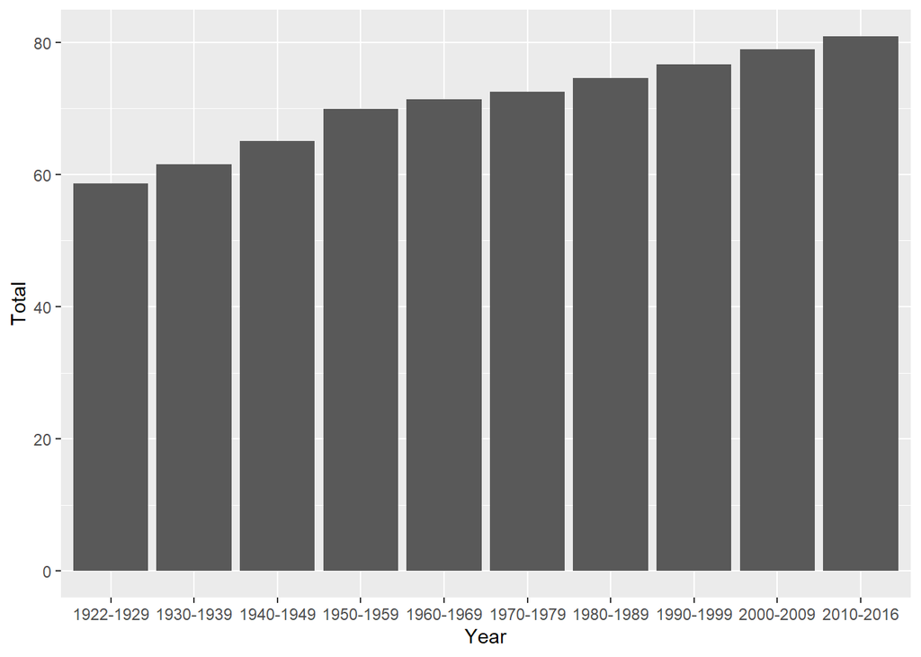

The bar chart shows life expectancy has increased steadily from 58.58 in 1922-29 to 80.87 in 2010-16. Increases in life expectancy seemed to be larger in earlier decades than in the latter part of the 20th century.

### Table - Female/Male Life Expectancy

[output not shown]

[figure not shown]